# 텍스트분석 뉴스레터: 2023년 1월

sung won kang

2023 5 17

- 한국환경연구원 텍스트 수집 도구는 2023년 5월 23일까지 네이버 기사 데이터와 환경부 문헌 데이터를 제공한다.아래 뉴스레터에서는 2023년 1월 31일을 기점으로 30일 이전까지 수집한 자료를 사용한다.

### A. Text 데이터

분석 대상 Text Data는 다음 두 종류의 문헌을 자료이다.

1. NAVER 환경 뉴스 : 2023년 1월 2일-2023년 1월 31일 NAVER 뉴스> ‘사회’ >‘환경’ 부문에 게시된 뉴스
2. 환경부 문건 : 2023년 1월 2일-2023년 1월 31일 환경부홈페이지에 게시된 환경부 보도자료 및 e-환경뉴스

’NAVER 환경 뉴스’는 환경정책의 수요자인 국민의 환경과 관련된 관심사를 전달하는 텍스트 자료이다. 그리고 ’환경부 문건’은 환경정책의 공급자인 환경부의 관심사를 전달하는 텍스트 자료이다. 이 두 자료의 키워드를 비교하여 환경정책 공급자의 관심사가 환경정책 수요자의 관심사에 조응하는지 여부를 점검한다.

### B. 키워드 빈도분석

한국환경연구원의 환경 빅데이터 플랫폼에서는 키워드를 단순빈도수 및 TF_IDF 값에 따라 추출한다. 키워드 추출 전단계로 파이선’konlpy’패키지를 활용한 형태소 분석 및 품사 태깅을 수행하고, 불용어(stopwords)를 제거한다. 2023년 1월 2일 - 1월 31일 게시 NAVER 환경뉴스 및 환경부 문건에서 단순빈도수가 높은 20개의 키워드를 추출한 결과는 아래 그림과 같다.

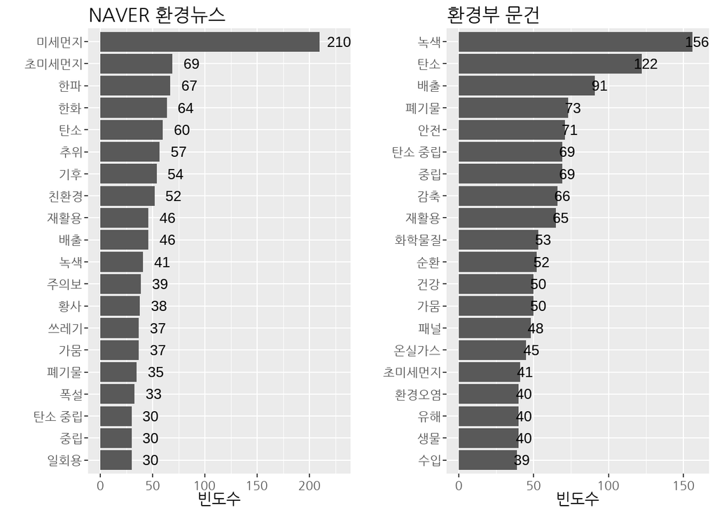

눈에 띄는 차이는 두 가지로 정리할 수 있다.

- 첫째, 네이버 환경뉴스에는 빈도수가 높은 상위 20개 키워드 중 ‘한파’,‘추위’,‘기후’,‘폭설’,‘황사’ 등 겨울철 기후 관련 키워드가 발견되었지만 환경부 문건의 빈도수 상위 20개 키워드에는 이에 상응하는 키워드가 발견되지 않았다.
- 둘째, 환경부 문건의 빈도수 상위 20개 키워드 중에는 ‘안전’,‘화학물질’,‘건강’,‘유해’ 등 환경안전 관련 키워드, ‘생물’과 같은 자연환경 관련 키워드, 그리고 ’수입’,‘패널’ 등의 키워드가 포함되지만 네이버 환경뉴스에서는 이에 상응하는 키워드가 발견되지 않았다.

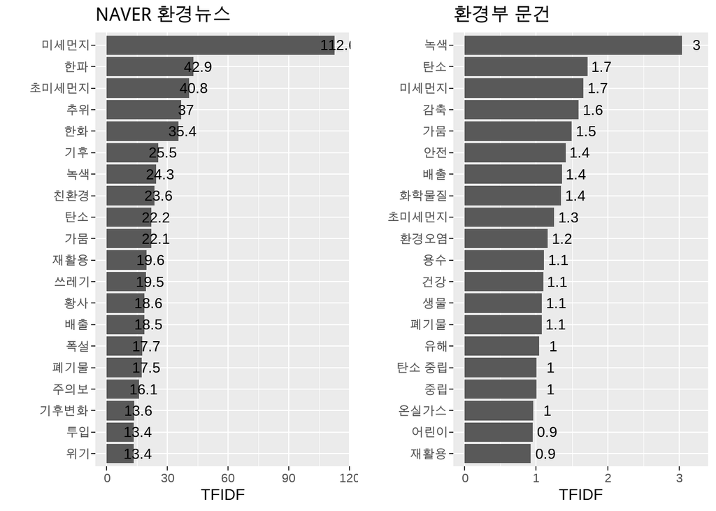

이와 같은 경향은 TF_IDF 값이 높은 20개의 키워드를 추출하여 비교하여도 확인된다. Figure 2는 TF_IDF를 기준으로 추출한 상위 20개 키워드의 TF_IDF 값을 보여준다. Figure 2에서도 확인할 수 있듯이

- “한파”,” 추위”,“기후”,“황사”,“폭설”,“주의보” 와 같은 키워드는 NAVER 뉴스에서만 찾아볼 수 있고
- “안전”,“화학물질”,“건강”,“생물”,“유해”,“어린이”와 같은 키워드들은 환경부 문건에서만 찾아 볼 수 있다.

### C. 키워드 관련 뉴스

네이버 환경뉴스 키워드와 환경부 문건 키워드간의 차이의 원인을 파악하기 위해서 두 문헌에서 단순빈도가 가장 높은 10개 키워드 중 서로 상이한 키워드가 포함된 문헌의 제목들을 비교하였다.

- 네이버 환경뉴스에서 단순빈도가 높은 10개 키워드 중 환경부 문건의 단순빈도가 높은 20개 키워드에 포함되지 않은 키워드는 [미세먼지, 한파, 한화, 추위, 기후, 친환경]이다.
- 환경부 문헌에서 단순빈도가 높은 10개 키워드 중 네이버 환경뉴스에서 단순빈도가 높은 20개 키워드에 포함되지 않은 키워드는 [안전, 감축, 화학물질]이다.
1. ‘한파’, ‘추위’를 제목에 포함하는 기사들은 1월 2일 발령된 한파 특보를 비롯하여 1월에 급격하게 하락한 기온 관련 기사들이 주종을 이룬다. 같은 기간 환경부 문헌 중에는 ’한파’,’추위’가 제목에 포함되는 문헌이 부재하였다.

| Title |
| --- |
| 중부지방 한파 특보…낮 최고 -4∼7도 |
| 연초부터 불어닥친 한파…당분간 평년 밑도는 기온에 6일 눈·비도 |
| [내일날씨] 중부내륙 -18도 한파…전라·제주 오전에 눈 |
| [내일날씨] 출근길 한파 지속…서울 아침 -9도 |
| [날씨]중부지방 또 한파 특보…낮 최고기온 -4~7도 |
| [내일날씨] ‘한파 계속’ 중부내륙 체감 -18도…전라·제주 오전 눈(종합) |
| [퇴근길날씨] 해 지면 체감 -15도 ‘한파’…강원·경상 ‘건조특보’ |
| 12월 한파·폭설에…전력수요 ‘역대 최고’ 기록 갈아치웠다 |
| 최저 –15도 강추위에 강풍도 5일까지…강원 영동·경상권 건조 |
| [날씨]전국 여전한 맹추위에 강한 바람…낮 기온 0도 안팎 |

2. ’친환경’을 제목에 포함하는 기사들은 친환경 포장재 관련 기사 및 강남구에서 도입하는 친환경 노명 청소기 관련 기사가 주종을 이루었다.같은 기간 환경부 문건 중 ’친환경’을 제목에 포함한 문건은 존재하지 않았다.

| Title |
| --- |
| 신세계백화점, 친환경박스 선물세트 선보여 |
| 이번 설 선물 포장은 친환경으로 |
| 콩기름 잉크로 만들어진 친환경 선물 박스 |
| 친환경 박스에 포장된 설 선물세트 |
| 신세계백화점, 설 선물 세트 친환경 포장 확대 |
| “불법 전단지도 빨아들인다” 강남구, 친환경 노면 청소기 도입 |
| 강남구, ‘친환경 노면 청소기’ 도입 |
| 강남구, 친환경 노면청소기 도입…“불법 전단지 흡입” |
| ‘버려진 종이로 회사 소식을’…제주관광공사 친환경 사보 ‘눈길’ |
| 사천해경, 친환경 위장 낚시 추 제조 판매한 업체 대표 검거 |

3. ’한화’를 제목에 포함하는 기사들은 한화진 환경부 장관 관련 기사가 주종을 이루었다.

| Title |
| --- |
| [신년사] 한화진 환경장관 “탄소중립 이행…물관리 패러다임 전환” |
| [신년사] 한화진 “탄소중립 목표 이행, 국가 도약 기회로” |
| [신년사]한화진 장관 “그린오션 시대…녹색강국 만들자” |
| 2023년 업무계획보고 브리핑하는 한화진·원희룡 장관 |
| 2023년 업무계획보고 브리핑하는 원희룡·한화진 장관 |
| 원희룡·한화진 장관, 2023년 업무계획보고 브리핑 |
| 2023년 업무계획보고 브리핑 앞둔 원희룡·한화진 |
| 브리핑룸 들어서는 원희룡·한화진 |
| 업무보고 브리핑하는 원희룡 장관과 한화진 장관 |
| 브리핑실 들어서는 원희룡 장관과 한화진 장관 |

4. ’기후’를 제목에 포함하는 기사들은 특정한 경향을 보여주지 않았다.

| Title |
| --- |
| ‘명화 훼손’ 과격시위에 여론 등돌리자…기후활동가 “그만할것” |
| 인권위 “기후위기 속 인권보호는 정부 기본의무” |
| 인권위 “기후위기 상황…정부가 인권 보호·증진 나서야” |
| 기후활동가, 프랑스 총리실 입구에 페인트 뿌리다 연행 |
| 존 케리 “부유한 국가들, 전세계 기후 분노에 대응해야” |
| 기후위기 해법 “우리가 연결되어 있음을 인식하는 것” |
| 프랑스, 지난해 가장 더웠다…“기후 변화 징후” |
| 5월 부산서 기후산업국제박람회…“2030엑스포 연계 CES급” |
| 화학연, ‘찾아가는 화학콘서트’ 개최…기후위기·탄소중립 특강 |
| 기후위기에 찾아온 희소식···인류 노력으로 2040년 오존층 원상복구 전망 |

환경부 문헌에서 가장 빈도가 높은 10개 키워드 중 네이버 뉴스에서 가장 빈도가 높은 키워드 20개에 포함되지 않은 키워드는 “안전”, “감축”, “화학물질” 이다. 2023년 1월 2일부터 1월 31일까지 게시된 환경부 문헌 중 이들 키워드를 제목에 포함하는 환경부 문헌은 다음과 같다.

1. ‘안전’을 제목에 포함하는 문헌은 어린이 환경안전망 문헌 1건, ’안전한 사회구현’ 관련 문헌 1건으로 특정한 추세를 보이지 않았다.

| Title |
| --- |
| 건강하고 안전한 어린이 환경안전망 구축 |
| 국민이 체감하는 환경적으로 안전하고 건강한 사회구현 |

2. ’화학물질’을 제목에 포함하는 문헌들은 유해화학물질 시설 현황 및 시설개선 사업에 관련된 문헌 3건이었다.

| Title |
| --- |
| 2023년도 유해화학물질 시설개선 지원사업 공고 |
| 2018년 대비 2020년 화학물질 취급업체 19.9% 증가 |
| 유해화학물질 취급사업장 무료 기술지원 받으세요 |

### D. 정리

2023년 1월 2일-2023년 1월 31일 게시된 네이버 환경뉴스와 환경부 문헌을 비교한 결과를 요약하면 다음과 같다.

1. 네이버 기사로부터 겨울철 한파에 대한 국민들의 관심이 많은데 이와 관련된 환경부 문건의 비중은 낮은 것으로 파악되었다. 이는 이상기후현상이 기후변화와 연관된 문제로서 환경문제로 인식은 되지만, 환경정책은 겨울철 이상기후현상에 대한 맞춤형 대응이 부족함을 시시한다.
2. 환경부 문헌으로부터 이 당시 환경부는 유해화학물질 배출 시설 현황 파악 및 관리 정책을 추진하고 있었음을 알 수 있다. 그러나 이러한 정책은 NAVER 뉴스의 관심을 얻지 못하였다.